# Практична робота №8

## **Тема. Жадібні алгоритми. Наближене розв’язання екстремальних задач**

## **Мета:** набути практичних навичок застосування деяких жадібних алгоритмів для розв’язання екстремальних задач.

### *Викoнав Міняйло Марк 25.05.24*

Заданий зважений граф: [(1,2,4), (1,3,5), (1,4,7), (1,5,8), (2,3,3), (2,4,4), (2,5,6), (3,4,2), (3,5,3), (4,5,1)]

**2) Візуалізувати граф.**

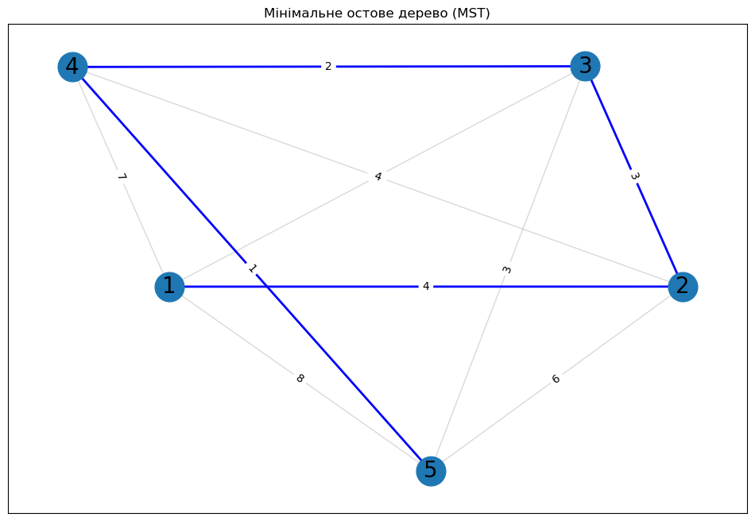

```python
import networkx as nx
import matplotlib.pyplot as plt

# Ініціалізація графа
G = nx.Graph()

# Додавання вузлів
G.add_nodes_from(range(1, 6))

# Додавання зважених ребер
edges = [(1, 2, 4), (1, 3, 5), (1, 4, 7), (1, 5, 8),
         (2, 3, 3), (2, 4, 4), (2, 5, 6),
         (3, 4, 2), (3, 5, 3), (4, 5, 1)]

G.add_weighted_edges_from(edges)

# Знаходження мінімального остового дерева за алгоритмом Крускала
mst = nx.minimum_spanning_tree(G, algorithm='kruskal')

# Візуалізація графа та MST
pos = nx.spring_layout(G)  # позиції для всіх вузлів

plt.figure(figsize=(12, 8))

# Відображення всіх вузлів
nx.draw_networkx_nodes(G, pos, node_size=700)
nx.draw_networkx_labels(G, pos, font_size=20, font_family='sans-serif')

# Відображення всіх ребер
nx.draw_networkx_edges(G, pos, edgelist=G.edges(), alpha=0.3, edge_color='grey')

# Відображення MST ребер
nx.draw_networkx_edges(G, pos, edgelist=mst.edges(), width=2, edge_color='blue')

# Відображення підписів ребер
edge_labels = dict([((u, v,), d['weight']) for u, v, d in G.edges(data=True)])
nx.draw_networkx_edge_labels(G, pos, edge_labels=edge_labels)

plt.title('Мінімальне остове дерево (MST)')
plt.show()
```

**3) Обґрунтувати асимптотику для обох алгоритмів, неведену в табл. 1.4.**

В алгоритмі найближчого сусіда - наспраді я бачу тільки два найвагоміші фрагмента коду, цикли зовнішній і внутрішній, це повинна бути алгоритмічна складність $O(n^2)$. Не розумію де в середині внутрішнього циклу взявся logn

В алгоритмі грубої сили вся велика складність знаходиться у функції node_permutations. У ній генеруються всі можливі перестановки вершин, починаючи з заданої початкової вершини, це вимагає склідності O(N!). Фактичну всю складність формує 1 рядок return [[init_node] + list(a_tuple) for a_tuple in permutations(nodes)]

# Контрольні запитання

1. *Що таке жадібний алгоритм?*

Жадібний алгоритм - це метод розв'язку задачі, в якому приймаються локальні оптимальні рішення на кожному кроці з метою знаходження глобальної оптимальності. Основна ідея полягає в тому, щоб на кожному кроці обирати найбільш вигідний варіант, не зважаючи на наслідки у майбутньому.

2. *Які головні принципи роботи жадібних алгоритмів?*

Жадібний алгоритм обирає кожен крок таким чином, щоб забезпечити найкращий можливий результат на даному етапі, не приділяючи уваги майбутнім наслідкам

3. *Яка головна відмінність між жадібними алгоритмами та динамічним програмуванням?*

Динамічне програмування вирішує складні задачі, розбиваючи їх на більш прості підзадачі і розв'язуючи кожну з них лише один раз, зберігаючи результати для майбутнього використання. Тобто основна ідея полягає в тому, щоб розв'язати кожну підзадачу лише один раз і зберігати її результат, щоб уникнути зайвих обчислень. А жадібний алгоритм просто обирає найкращий варінт

4. _Наведіть приклади задач, які можна розв’язати за допомогою жадібних алгоритмів.___

Задача про рюкзак, задача Комівояжора.

5. *Які можуть бути обмеження у використанні жадібних алгоритмів для розв'язання екстремальних задач?*

Жадібні алгоритми не ураховують глобальні оптимальні рішення, а лише оцінюють доступні альтернативи на поточному етапі. Ефективність жадібних алгоритмів може залежати від початкових умов і вхідних даних. Жадібні алгоритми можуть призводити до рішень, які не є оптимальними у глобальному контексті.

6. *Чому жадібні алгоритми часто використовуються для наближеного розв’язання екстремальних задач?*

Бо вони не витрачають гіганську кількість ресурсів і часу, також вони є простими у реалізації